# Les pêcheurs de perles

## Handlung

ERSTER AKT  
An einem Strand im Indischen Ozean. Wie jedes Jahr beginnt zu dieser Jahreszeit das Tauchen nach den kostbaren Perlen, und die Fischer haben sich um ihren Anführer Zurga versammelt. Mit ihren Gesängen bitten sie die Götter um Schutz vor Gefahren und vor dem Unbill der Natur. Da erscheint Nadir, der die Gemeinschaft der Perlenfischer vor Jahren verlassen hat und seitdem durch die Welt gereist ist. Der Heimkehrer wird von allen freudig wieder aufgenommen, vor allem von Zurga, mit dem ihn von Jugend an eine tiefe Freundschaft verbindet. Wir erfahren, dass dieser Bund vor Jahren zu zerbrechen drohte, als sich die beiden auf ihrer letzten gemeinsamen Reise unsterblich in dieselbe unbekannte Schöne verliebt hatten. Um nicht zu Feinden zu werden, hatten sie damals beschlossen, beide für immer der Liebe zu dieser »Göttin« zu entsagen. In der Erinnerung an dieses Erlebnis bekräftigen die beiden Männer erneut ihre Verbundenheit. Nadir scheint aber zögerlich zu sein …  
Kurze Zeit später: Die Gemeinschaft wartet auf die Ankunft einer Priesterin, die für das Wohl der Perlenfischer singen und beten soll, um die Götter freundlich zu stimmen und die bösen Geister zu bannen. Der Oberpriester Nourabad führt die verschleierte Frau schließlich an den Strand. Zurga nimmt der Unbekannten den Schwur ab, für die Dauer ihres Aufenthaltes abgeschieden und ohne Mann unter ihnen zu leben, um sich ganz ihrer Aufgabe zu widmen. Als Lohn erwartet sie die kostbarste Perle, der Bruch dieses Versprechens aber würde ihren Tod bedeuten. Nadir weiß schon, wer die verschleierte Priesterin ist, ihretwegen ist er hier. Und auch sie sieht ihn für einen kurzen Moment und ist zutiefst erschrocken. Zurga, der ihre plötzliche Panik bemerkt, bietet ihr an, von ihrem Gelübde doch noch Abstand zu nehmen, bevor es zu spät ist, aber sie fasst sich, lehnt ab und leistet den Schwur. Die Perlenfischer rufen den Gott Brahma an, bevor der Abend hereinbricht …  
Nadir ist von Gewissensbissen geplagt. Er hätte Zurga gestehen sollen, daß er damals schon sein Versprechen gebrochen und sich heimlich mit dieser Frau getroffen hatte, mit Leïla. Seitdem ist ihre verbotene Liebe zueinander entbrannt. Und jetzt verrät Nadir seinen Freund erneut, indem er der Geliebten bis hierher gefolgt ist. Er wusste bloß nicht, dass Leïla hier eine Aufgabe hat, die es für sie beide lebensgefährlich macht, sich zu sehen. Nadir leidet an seinem Liebeskummer und versenkt sich zugleich in der Vorstellung seiner Liebe zu Leïla.  
Nourabad fordert Leïla auf, ihres Amtes zu walten und hoch oben auf einem Felsen zu singen, um die Götter um Schutz für die Perlenfischer anzuflehen. Dann lässt der alte Mann sie allein. Sie weiß, dass sie nicht nur hoch zum Himmel singt, sondern auch einen heimlichen Zuhörer hat, Nadir. Sie fühlt sich von ihm beschützt und mehr denn je zu ihm hingezogen …

ZWEITER AKT  
Für diese Nacht ist Leïlas Arbeit getan. Nourabad bringt sie an einen entlegenen heiligen Ort, sicher bewacht, wo sie schlafen kann. Er bestärkt sie, dass sie dort absolut ungefährdet sei. Leïla vertraut sich dem Alten an und erzählt ihm, wie sie als Kind schon einmal eine höchst gefährliche Situation erlebt hat. Unter Einsatz ihres Lebens hatte sie einem Flüchtling das Leben gerettet, der ihr zum Dank eine Perlenkette gab, die sie seitdem immer trägt. Nourabad hört ihre Geschichte, dann lässt er Leïla allein zurück.  
Leïla fürchtet sich in ihrer Einsamkeit, tröstet sich aber mit dem Gedanken, dass der Geliebte irgendwo da draußen in ihrer Nähe ist. Und dann taucht Nadir tatsächlich aus dem Dunkel auf! Er hat das Unmögliche wahr gemacht und ist über die Klippen, an den Wachen vorbei, bis zu ihr vorgedrungen. Zunächst weist sie ihn erschrocken ab: Nur zu leicht könnten sie entdeckt und mit dem Tod bestraft werden. Die Liebe aber ist stärker: Wechselseitig gestehen sie sich ihre bedingungslose Zuneigung.  
Ein Gewitter erhebt sich. Leïla bittet Nadir zu gehen, in der nächsten Nacht aber könne er wieder zu ihr kommen. Doch unmittelbar vor seinem Abschied werden die beiden von Nourabad überrascht, der ob Leïlas Treuebruch Zeter und Mordio ruft. Nadir flieht, wird aber von den Fischern gefangen genommen. In Gegenwart der gesamten Gemeinschaft verkündet Nourabad die notwendige Hinrichtung der beiden Liebenden. Nur so könnten die Götter befriedet werden, deren Zorn sich in dem gewaltigen Sturm offenbart, der nun über sie hereinbricht.  
In letzter Sekunde tritt Zurga dazwischen: Mit all seiner Autorität verfügt er die Freilassung des Paares, um seinen Freund zu retten. Murrend fügt sich das Volk. Nur Nourabad will den Frevel nicht dulden und zieht den Schleier von Leilas Gesicht, um sie vor allen Leuten bloßzustellen. Jetzt erkennt Zurga zu seinem größten Entsetzen, dass es sich bei der Fremden um ebenjene »Göttin« handelt, um die er vor Jahren mit Nadir konkurriert hatte. Ein heiliger Zorn über den Verrat seines Freundes entbrennt in ihm, und er verurteilt Nadir und Leïla nun endgültig: Am nächsten Morgen müssen sie sterben!

DRITTER AKT  
Noch in derselben Nacht. Der Sturm hat sich gelegt. Zurga bedauert seine im Zorn und aus dem Affekt heraus getroffene Entscheidung. Seine Freundschaft zu Nadir gewinnt die Oberhand, und er ist bereit, sein Urteil zu widerrufen, als Leïla in seinem Zelt auftaucht. Sie will um Gnade für Nadir bitten und bietet ihren eigenen Tod als Opfergabe an. Da erst begreift Zurga, wie sehr die beiden einander lieben. Seine eigene über Jahre verdrängte Liebe zu Leïla flammt wieder auf, auch die Enttäuschung darüber, so lange schon der Hintergangene gewesen zu sein. Er gesteht der entsetzten Leïla seine große Liebe zu ihr und gerät dabei in eine solche glühende Eifersucht, dass er das Todesurteil für beide noch einmal bekräftigt, so sehr Leïla auch um Gnade für Nadir bittet. Ihre Verachtung für Zurga kennt nun keine Grenze mehr: Sie schreit ihm ihren Hass ins Gesicht, während Zurga sich in ohnmächtiger Raserei vor ihr windet.  
Als Leïla abgeführt wird, fasst sie sich und findet ihren Stolz wieder. Sie übergibt ihre Perlenkette einem Fischer und bittet ihn, diese ihrer Mutter zu überbringen. Zurga erkennt in dieser Kette ebenjenes Dankeszeichen, dass er einst einem Mädchen gegeben hat, das ihn aus höchster Gefahr gerettet hat. Er begreift, wen er da gerade in den Tod schickt …  
Im Morgengrauen soll unter Nourabads Aufsicht die Hinrichtung vollzogen werden. Die Fischer haben sich schon in eine Art Trance gesungen und können es nicht erwarten, dass die Sonne aufgeht. Die beiden Liebenden sind bereit, gemeinsam zu sterben. Da unterbricht Zurga die Zeremonie: Was alle für die Morgenröte hielten, ist in Wirklichkeit ihr Dorf, das in Flammen steht. Sie sollten rennen, um ihre Kinder und ihr Hab und Gut zu retten. In Panik läuft das Volk davon. Zurga, Leïla und Nadir bleiben allein zurück. Zurga löst die Liebenden von ihren Fesseln. Er gesteht, selbst die Hütten der Perlenfischer in Brand gesetzt zu haben. Die Freundschaft und die Macht der Liebe haben gesiegt, Leïla und Nadir fliehen. Zurga bleibt allein zurück. Er weiß, dass er das Richtige getan hat, auch wenn seine eigene Zukunft ungewiss ist.

## Programmbuch

[Download](https://www.staatsoper-berlin.de/downloads-b/de/produktion/3/programmbuch/6cbefd96b41c00cfea242cb2e86e58bf/Les%20P%C3%AAcheurs%20de%20perles_Programmheft_Web.pdf)

## Mehr erfahren

### »Ich würde mir wünschen, dass Georges Bizet im Komponistenhimmel sich darüber freut«

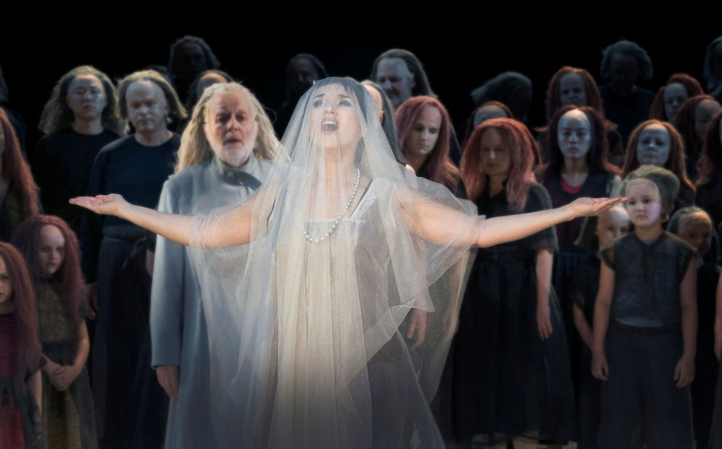

- Im Interview mit Chefdramaturg Detlef Giese verriet der Regisseur, warum er für sein Debüt die »Perlenfischer« wählte und wie Daniel Barenboim auf seinen Vorschlag reagierte.
- Koproduktion mit dem China National Centre of the Performing Arts (NCPA), Peking/China